# Laboratorio 2

Erik De Luca

2022-10-21

## Analisi dei dati

```r
tl = read.csv("dataset/TL.csv") %>% tibble %>% dplyr::select(-X)
tl = tl %>% mutate_at(c( "MARSTAT"), as.factor)
tl
```

| AGE | MARSTAT | EDUCATION | NUMHH | INCOME | FACE |
| --- | --- | --- | --- | --- | --- |
| 30 | not single | 16 | 3 | 43000 | 20000 |
| 50 | not single | 9 | 3 | 12000 | 130000 |
| 39 | not single | 16 | 5 | 120000 | 1500000 |
| 43 | not single | 17 | 4 | 40000 | 50000 |
| 34 | not single | 11 | 4 | 28000 | 220000 |
| 29 | not single | 16 | 3 | 100000 | 600000 |
| 72 | not single | 17 | 2 | 112000 | 100000 |
| 51 | not single | 16 | 4 | 15000 | 2500000 |
| 58 | single | 14 | 1 | 32000 | 250000 |
| 73 | not single | 12 | 2 | 25000 | 50000 |

[output cut: 265 more lines]

```r
#"NUMHH", "EDUCATION",
```

## Trasformazione variabili

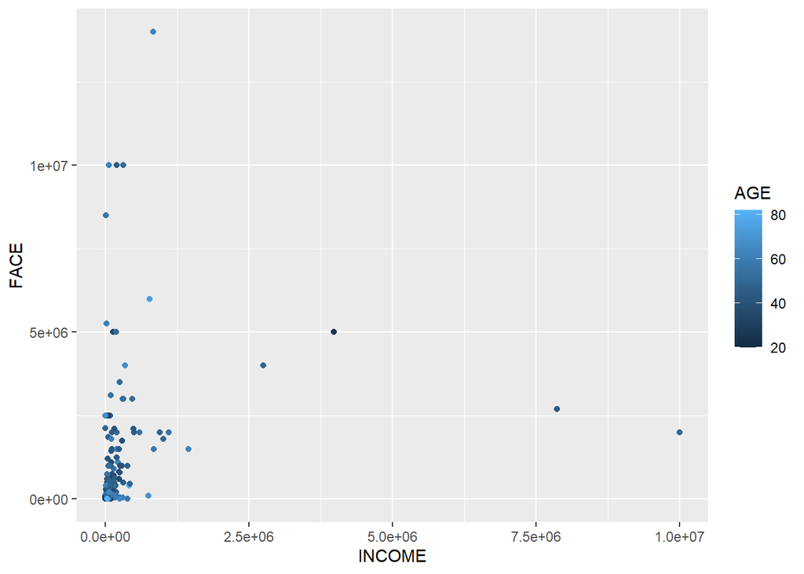

```r
ggplot(tl, aes(y = FACE, x = INCOME, col = AGE)) +
  geom_point()
```

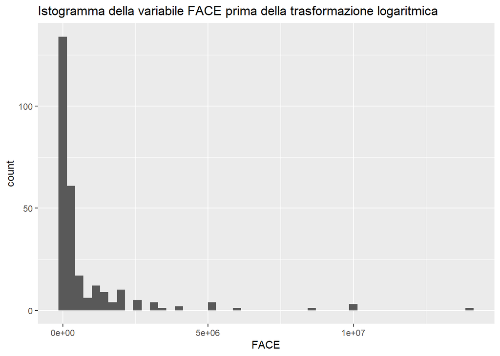

```r
ggplot(tl,aes(x = FACE)) +
  geom_histogram(bins = 50) +
  labs(title = "Istogramma della variabile FACE prima della trasformazione logaritmica")
```

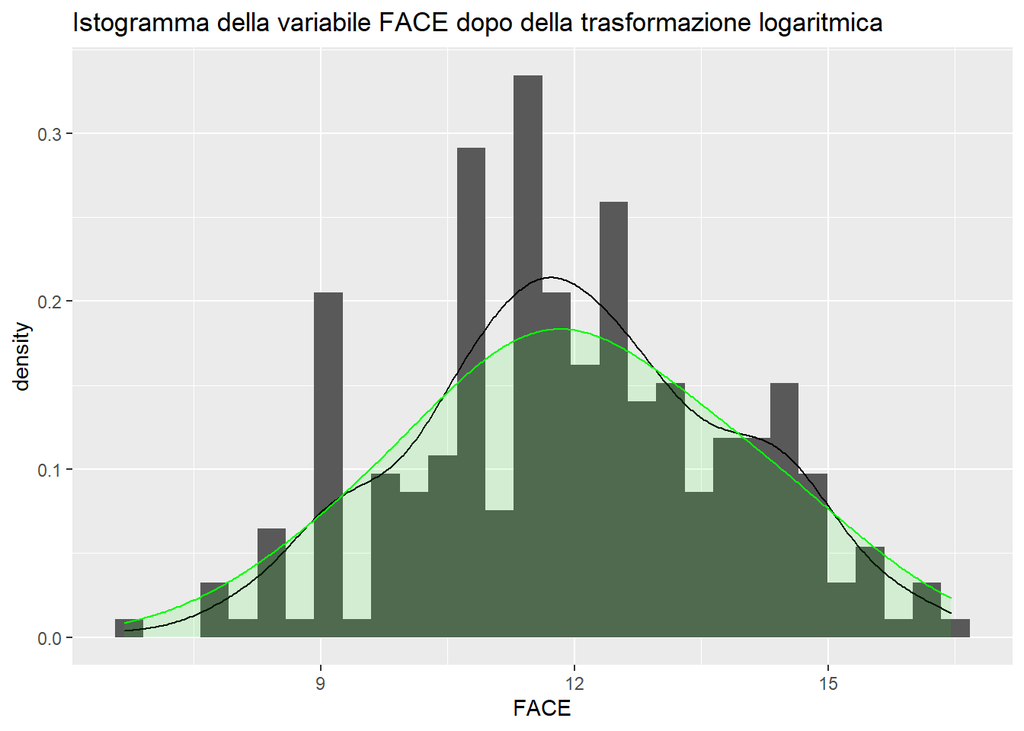

```r
tl = tl %>% mutate_at(c("FACE","INCOME"),log)
ggplot(tl,aes(x = FACE, y = ..density..)) +
  geom_histogram(bins = 30,) +
  geom_density() +
  geom_density(color = "green",
               fill = "green",
               alpha = 0.1, # densità del colore
               kernel = "gaussian",
               adjust = 2) +
  labs(title = "Istogramma della variabile FACE dopo della trasformazione logaritmica")
```

## Modello

```r
# train = sample(c(1:dim(tl)[1]), .7*dim(tl)[1], replace = F)
set.seed(1)
train = createDataPartition(tl$AGE,p = .8,list = F)
modAll = lm(FACE ~ ., data = tl, subset = train)
gtsummary::tbl_regression(modAll)
```

| **Characteristic** | **Beta** | **95% CI**<sup>1</sup> | **p-value** |
| --- | --- | --- | --- |
| AGE | -0.01 | -0.02, 0.01 | 0.5 |
| MARSTAT |  |  |  |
| not single | — | — |  |
| single | -0.42 | -1.0, 0.16 | 0.2 |
| EDUCATION | 0.19 | 0.10, 0.27 | <0.001 |
| NUMHH | 0.25 | 0.09, 0.42 | 0.002 |
| INCOME | 0.42 | 0.25, 0.60 | <0.001 |

<sup>1</sup> CI = Confidence Interval

```r
modFor = regsubsets(FACE ~ .,data = tl[train,],method = "forward")
modFor %>% summary
```

```
## Subset selection object
## Call: regsubsets.formula(FACE ~ ., data = tl[train, ], method = "forward")
## 5 Variables  (and intercept)
##               Forced in Forced out
## AGE               FALSE      FALSE
## MARSTATsingle     FALSE      FALSE
## EDUCATION         FALSE      FALSE
## NUMHH             FALSE      FALSE
## INCOME            FALSE      FALSE
## 1 subsets of each size up to 5
## Selection Algorithm: forward
##          AGE MARSTATsingle EDUCATION NUMHH INCOME
## 1  ( 1 ) " " " "           " "       " "   "*"
## 2  ( 1 ) " " " "           " "       "*"   "*"
## 3  ( 1 ) " " " "           "*"       "*"   "*"
## 4  ( 1 ) " " "*"           "*"       "*"   "*"
## 5  ( 1 ) "*" "*"           "*"       "*"   "*"
```

```r
modBack = MASS::stepAIC(modAll,direction = "backward")
```

```
## Start:  AIC=200.54
## FACE ~ AGE + MARSTAT + EDUCATION + NUMHH + INCOME
##
##             Df Sum of Sq    RSS    AIC
## - AGE        1     0.993 520.03 198.97
## <none>                   519.04 200.54
## - MARSTAT    1     4.873 523.91 200.62
## - NUMHH      1    22.803 541.84 208.09
## - EDUCATION  1    45.512 564.55 217.20
## - INCOME     1    55.565 574.60 221.12
##
## Step:  AIC=198.97
## FACE ~ MARSTAT + EDUCATION + NUMHH + INCOME
##
##             Df Sum of Sq    RSS    AIC
## - MARSTAT    1     4.289 524.32 198.79
## <none>                   520.03 198.97
## - NUMHH      1    29.582 549.61 209.25
## - EDUCATION  1    44.711 564.74 215.28
## - INCOME     1    55.019 575.05 219.29
##
## Step:  AIC=198.79
## FACE ~ EDUCATION + NUMHH + INCOME
##
##             Df Sum of Sq    RSS    AIC
## <none>                   524.32 198.79
## - EDUCATION  1    44.334 568.65 214.81
## - NUMHH      1    48.977 573.30 216.62
## - INCOME     1    62.961 587.28 221.97
```

## Scelta del modello

```r
predAll = predict.lm(modAll,newdata = tl[-train,])
predBack = predict.lm(modBack,newdata = tl[-train,])
data.frame(R2 = c(R2(predAll,tl[-train,"FACE"]),R2(predBack,tl[-train,"FACE"])),
           row.names = c("Tutte le variabili", "Backward"))
```

|  | R2 |
| --- | --- |
| Tutte le variabili | 0.5412720 |
| Backward | 0.5220814 |

### Validation set

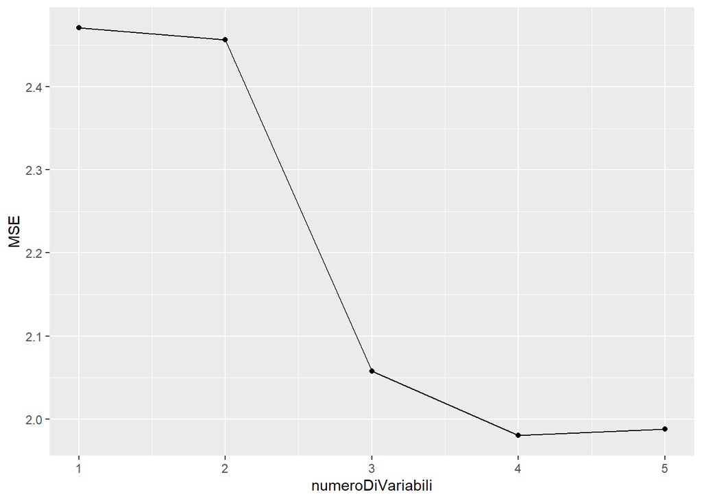

```r
testMat = model.matrix(FACE~., data = tl[-train,])

valErr = sapply(c(1:(length(tl)-1)),function(i) mean((tl$FACE[-train]-testMat[,names(coef(modFor, id = i))]%*%coef(modFor, id = i))^2))
ggplot(data.frame(MSE = valErr, numeroDiVariabili = c(1:5)),
       mapping = aes(y = MSE, x = numeroDiVariabili)) +
  geom_line() +
  geom_point()
```

### Cross validation

Siccome non esiste il metodo `predict` per `regsubset` necessitiamo allora di specificarlo prima di poterlo chiamare in modo da semplificare i calcoli successivi. Nel punto precedento, invece, è stata scritta l’intera procedura. Si poteva seguire lo stesso procedimento anche in questo caso.

Il pezzo di codice che definisce la funzione `predict` (copiato da web) è stato poi adattato in modo tale che potesse ricevere in input oggetti provenienti da liste o funzioni.

```r
predict.regsubsets = function(object, newdata, id, form = NULL, ...)
{
  if(is.null(form))
    form = as.formula(object$call[[2]])
  mat = model.matrix(form, newdata)
  coefi = coef(object, id = id)
  mat[, names(coefi)] %*% coefi
}
```

Nel seguente pezzo di codice si poteva evitare di utilizzare la funzione `map_dfc` andado a calcolare il valore medio fuori dal `sapply` ottenendo così un unico e valore, e successivamente applicare un altro `sapply` ottenendo questa volta un vettore anziché un dataframe.

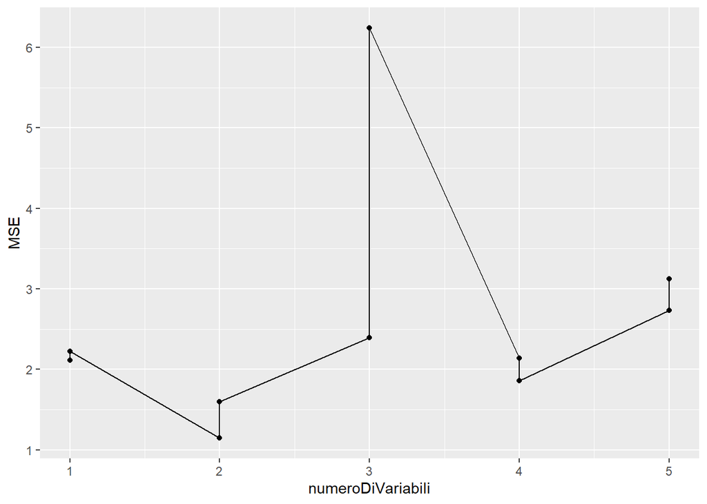

```r
k = 10        # numero di folds
set.seed(1)
folds = sample(1:k, nrow(tl), replace = TRUE)

cvErr = purrr::map_dfc(c(1:k),function(j) sapply(c(1:5),function(i) mean((tl$FACE[folds==j]-predict(regsubsets(FACE~., data = tl[folds!=j,], nvmax=6), tl[folds == j,], id = i,form = as.formula(FACE~.)))^2)))
cvErrMean = apply(cvErr,2,mean)

ggplot(data.frame(MSE = cvErrMean, numeroDiVariabili = c(1:5)),
       mapping = aes(y = MSE, x = numeroDiVariabili)) +
  geom_line() +
  geom_point()
```

Dal grafico soprastante si deduce che il miglior modello in questo caso è quello con 2 variabili.

## Ridge e Lasso

```r
matTl = makeX(tl[,names(tl)!="FACE"])


# per trovare lambda ottimale attraverso cross validation
cvRidge = cv.glmnet(matTl,
                    tl$FACE,
                    alpha = 0)

cvLasso = cv.glmnet(matTl,
                    tl$FACE,
                    alpha = 1)


# lambda ottimale
data.frame(Ridge = cvRidge$lambda.min,
           Lasso = cvLasso$lambda.min,
           row.names = "Lambda ottimale")
```

|  | Ridge | Lasso |
| --- | --- | --- |
| Lambda ottimale | 0.3309644 | 0.003717803 |